# Are we confounded by genes that aren’t real?

Stephanie J. Spielman

2025-02-26

This notebook compares model residual distributions between gene with symbol annotations and genes without. We have wondered if genes without annotation, which are less likely to be “real” genes, are biasing our downstream analyses.

## Setup

```r
renv::load()
```

```
- Project '~/ALSF/scpca-paper-figures' loaded. [renv 1.1.0]
```

```r
library(ggplot2)
theme_set(theme_bw())
```

### Paths

```r
model_dir <- here::here("analysis", "pseudobulk-bulk-prediction", "results", "models")
ensembl_symbol_df <- readr::read_tsv(
  here::here("analysis", "bulk-deconvolution", "data", "reference", "ensembl_symbol.tsv"),
  show_col_types = FALSE
)
```

### Functions

This chunk defines a function for loading and preparing residual data.

```r
read_prepare_data <- function(file_pattern, ensembl_symbol_df) {

  model_files <- list.files(
    path = model_dir,
    full.names = TRUE,
    pattern = file_pattern
  ) |>
    purrr::set_names(
      \(f) {stringr::str_split_i(basename(f), pattern = "_", i = 1)}
    )

  model_files |>
    purrr::map(
      \(model_file) {
        model_data <- readr::read_rds(model_file)

        residuals_df <- model_data$data |>
          dplyr::mutate(residuals = unname(resid(model_data$model))) |>
          dplyr::left_join(ensembl_symbol_df, by = "ensembl_id") |>
          # If the join resulted in an NA, then it's not annotated
          dplyr::mutate(status = ifelse(
            is.na(gene_symbol),
            "not_annotated",
            "annotated"
          ))
    }) |>
    purrr::list_rbind(names_to = "project_id")
}
```

This chunk defines a function for plotting histograms.

```r
make_histogram <- function(df, xvar, title) {
  ggplot(df) +
    aes(x = {{xvar}}, y = after_stat(ndensity), fill = status) +
    geom_histogram(position = "identity", alpha = 0.45, bins = 100) +
    facet_grid(rows = vars(project_id)) +
    scale_fill_brewer(palette = "Set1") +
    ggtitle(title)
}
```

This chunk defines a function for modeling and viewing results.

```r
fit_model <- function(df) {

  fit <- summary(lm(residuals ~ status * project_id, data = df))
  diff_table <- df |>
    split(df$project_id) |>
    purrr::map(
      \(df_){
      mean(df_$residuals[df_$status == "annotated"]) - mean(df_$residuals[df_$status == "not_annotated"])
    })

  return(list(fit, diff_table))
}
```

This chunk defines a function for calculating the ratio of annotated to unannotated genes per project.

```r
calculate_ratio <- function(df) {
  df |>
    dplyr::select(project_id, ensembl_id, status) |>
    dplyr::distinct() |>
    dplyr::group_by(project_id) |>
    dplyr::count(status) |>
    tidyr::pivot_wider(names_from = status, values_from = n) |>
    dplyr::mutate(ratio = annotated/not_annotated)
}
```

## Unfiltered data

We’ll start by exploring this question for residuals whose models included *all* genes.

```r
unfiltered_df <- read_prepare_data("all-genes\\.rds$", ensembl_symbol_df)
```

Do the residuals have different distributions based on gene annotation status?

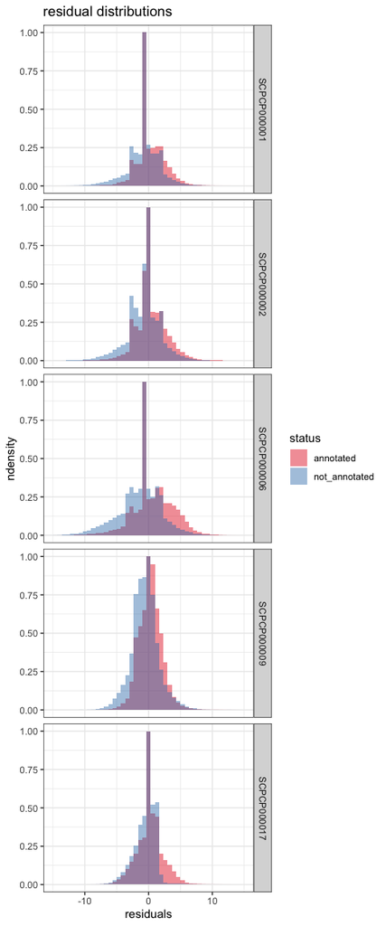

```r
make_histogram(unfiltered_df, residuals, "residual distributions") +
  coord_cartesian(xlim= c(-15, 15))
```

It appears that the residuals for annotated genes are slightly higher than residuals for genes without annotations. Let’s fit a quick linear model to check how much, and also look at the mean difference among projects directly. From the plots above, there doesn’t look to be much difference among samples, so we’ll fit one regression with a project interaction effect.

```r
fit_model(unfiltered_df)
```

```
[[1]]

Call:
lm(formula = residuals ~ status * project_id, data = df)

Residuals:
    Min      1Q  Median      3Q     Max
-18.259  -1.354  -0.005   1.367  46.372

Coefficients:
                                           Estimate Std. Error  t value Pr(>|t|)
(Intercept)                                0.307969   0.003102   99.272  < 2e-16 ***
statusnot_annotated                       -0.928762   0.005387 -172.395  < 2e-16 ***
project_idSCPCP000002                      0.020654   0.004326    4.775 1.80e-06 ***
project_idSCPCP000006                      0.317337   0.003781   83.921  < 2e-16 ***
project_idSCPCP000009                     -0.041301   0.007108   -5.810 6.24e-09 ***
project_idSCPCP000017                     -0.086536   0.004091  -21.152  < 2e-16 ***
statusnot_annotated:project_idSCPCP000002 -0.062289   0.007512   -8.292  < 2e-16 ***
statusnot_annotated:project_idSCPCP000006 -0.957013   0.006567 -145.737  < 2e-16 ***
statusnot_annotated:project_idSCPCP000009  0.124554   0.012344   10.090  < 2e-16 ***
statusnot_annotated:project_idSCPCP000017  0.260973   0.007105   36.732  < 2e-16 ***
---
Signif. codes:  0 ‘***’ 0.001 ‘**’ 0.01 ‘*’ 0.05 ‘.’ 0.1 ‘ ’ 1

Residual standard error: 2.567 on 5846471 degrees of freedom
Multiple R-squared:  0.05554,   Adjusted R-squared:  0.05554
F-statistic: 3.82e+04 on 9 and 5846471 DF,  p-value: < 2.2e-16


[[2]]
[[2]]$SCPCP000001
[1] 0.9287619

[[2]]$SCPCP000002
[1] 0.9910508

[[2]]$SCPCP000006
[1] 1.885775

[[2]]$SCPCP000009
[1] 0.8042081

[[2]]$SCPCP000017
[1] 0.6677892
```

Let’s contextualize these values with some expression distributions too.

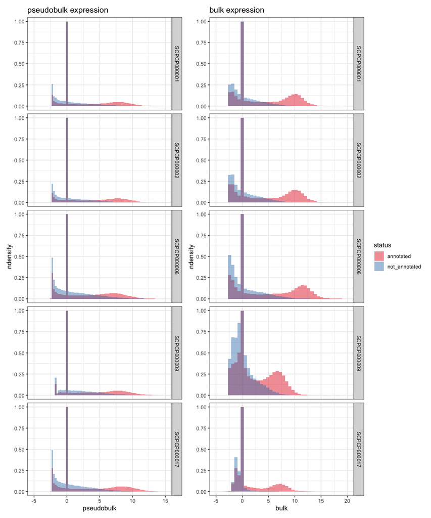

```r
list(
  make_histogram(unfiltered_df, pseudobulk, "pseudobulk expression") +
   coord_cartesian(xlim= c(-5, 15)),
  make_histogram(unfiltered_df, bulk, "bulk expression") +
    coord_cartesian(xlim= c(-5, 20))
) |>
  patchwork::wrap_plots(nrow = 1, guides = 'collect')
```

As expected, annotated genes have generally higher expression.

## Filtered data

Does this persist after our gene filtering was applied? We’ll look at this for the two expression thresholds we’ve run so far:

- `0`: Averaging modalities, the gene should be expressed in at least 1 sample
- `0.25`: Averaging modalities, the gene should be expressed in at least 25% of samples

### Expression threshold: 0

```r
filtered_df <- read_prepare_data("threshold-0\\.rds$", ensembl_symbol_df)
```

```r
fit_model(filtered_df)
```

```
[[1]]

Call:
lm(formula = residuals ~ status * project_id, data = df)

Residuals:
    Min      1Q  Median      3Q     Max
-17.905  -1.703   0.131   1.755  46.142

Coefficients:
                                           Estimate Std. Error  t value Pr(>|t|)
(Intercept)                                0.447556   0.003968  112.784  < 2e-16 ***
statusnot_annotated                       -1.313260   0.006798 -193.197  < 2e-16 ***
project_idSCPCP000002                      0.011412   0.005508    2.072  0.03828 *
project_idSCPCP000006                      0.352460   0.004761   74.036  < 2e-16 ***
project_idSCPCP000009                     -0.163419   0.008360  -19.547  < 2e-16 ***
project_idSCPCP000017                     -0.172722   0.005191  -33.275  < 2e-16 ***
statusnot_annotated:project_idSCPCP000002 -0.030376   0.009430   -3.221  0.00128 **
statusnot_annotated:project_idSCPCP000006 -1.000383   0.008137 -122.943  < 2e-16 ***
statusnot_annotated:project_idSCPCP000009  0.486041   0.014278   34.042  < 2e-16 ***
statusnot_annotated:project_idSCPCP000017  0.514514   0.008874   57.981  < 2e-16 ***
---
Signif. codes:  0 ‘***’ 0.001 ‘**’ 0.01 ‘*’ 0.05 ‘.’ 0.1 ‘ ’ 1

Residual standard error: 2.828 on 4684571 degrees of freedom
Multiple R-squared:  0.07341,   Adjusted R-squared:  0.0734
F-statistic: 4.123e+04 on 9 and 4684571 DF,  p-value: < 2.2e-16


[[2]]
[[2]]$SCPCP000001
[1] 1.31326

[[2]]$SCPCP000002
[1] 1.343635

[[2]]$SCPCP000006
[1] 2.313643

[[2]]$SCPCP000009
[1] 0.8272185

[[2]]$SCPCP000017
[1] 0.798746
```

One wonders, what’s the ratio of annotated to not annotated genes for each version of the data (unfiltered and filtered)? The unfiltered should be the same for all projects, but filtered will be different -

```r
calculate_ratio(unfiltered_df)
```

| project_id | annotated | not_annotated | ratio |
| --- | --- | --- | --- |
| SCPCP000001 | 40287 | 19986 | 2.015761 |
| SCPCP000002 | 40287 | 19986 | 2.015761 |
| SCPCP000006 | 40287 | 19986 | 2.015761 |
| SCPCP000009 | 40287 | 19986 | 2.015761 |
| SCPCP000017 | 40287 | 19986 | 2.015761 |

Ah, well that’s a nice check for free!

```r
# arbitrarily pick project 1 tpm as a spot that has the expected present IDs
bulk_ensembls <- readr::read_tsv(
  here::here("analysis", "pseudobulk-bulk-prediction", "data", "tpm", "SCPCP000001_tpm.tsv")
) |>
  dplyr::distinct(ensembl_id) |>
  dplyr::pull(ensembl_id)
ensembl_symbol_df |>
  dplyr::filter(ensembl_id %in% bulk_ensembls) |>
  dplyr::summarize(
    annotated = sum(!is.na(gene_symbol)),
    unannotated = sum(is.na(gene_symbol)),
    ratio = annotated/unannotated
)
```

| annotated | unannotated | ratio |
| --- | --- | --- |
| 40287 | 19986 | 2.015761 |

Looking good!

Now, how did filtering change this ratio?

```r
calculate_ratio(filtered_df)
```

| project_id | annotated | not_annotated | ratio |
| --- | --- | --- | --- |
| SCPCP000001 | 29879 | 15447 | 1.934291 |
| SCPCP000002 | 30447 | 15796 | 1.927513 |
| SCPCP000006 | 33038 | 17462 | 1.891994 |
| SCPCP000009 | 36929 | 19321 | 1.911340 |
| SCPCP000017 | 31061 | 16294 | 1.906285 |

After filtering, the ratio of `annotated:not_annotated` goes down. This means we have reduced our share of annotated genes during the filtering, which maybe was not in the spirit of the filtering or suggests that our current filtering strategy may need to shift.

### Expression threshold: 0.25

```r
filtered_df <- read_prepare_data("threshold-0.25\\.rds$", ensembl_symbol_df)
```

```r
fit_model(filtered_df)
```

```
[[1]]

Call:
lm(formula = residuals ~ status * project_id, data = df)

Residuals:
    Min      1Q  Median      3Q     Max
-16.492  -1.806   0.207   1.987  41.672

Coefficients:
                                           Estimate Std. Error  t value Pr(>|t|)
(Intercept)                                0.611043   0.004913  124.375  < 2e-16 ***
statusnot_annotated                       -2.124936   0.009162 -231.938  < 2e-16 ***
project_idSCPCP000002                      0.034759   0.006844    5.079 3.79e-07 ***
project_idSCPCP000006                      0.431440   0.005898   73.152  < 2e-16 ***
project_idSCPCP000009                     -0.182736   0.010521  -17.369  < 2e-16 ***
project_idSCPCP000017                     -0.292271   0.006516  -44.857  < 2e-16 ***
statusnot_annotated:project_idSCPCP000002 -0.105222   0.012740   -8.259  < 2e-16 ***
statusnot_annotated:project_idSCPCP000006 -1.218871   0.010867 -112.163  < 2e-16 ***
statusnot_annotated:project_idSCPCP000009  0.804134   0.018731   42.931  < 2e-16 ***
statusnot_annotated:project_idSCPCP000017  0.981787   0.012232   80.263  < 2e-16 ***
---
Signif. codes:  0 ‘***’ 0.001 ‘**’ 0.01 ‘*’ 0.05 ‘.’ 0.1 ‘ ’ 1

Residual standard error: 3.081 on 3316015 degrees of freedom
Multiple R-squared:  0.1244,    Adjusted R-squared:  0.1244
F-statistic: 5.234e+04 on 9 and 3316015 DF,  p-value: < 2.2e-16


[[2]]
[[2]]$SCPCP000001
[1] 2.124936

[[2]]$SCPCP000002
[1] 2.230159

[[2]]$SCPCP000006
[1] 3.343808

[[2]]$SCPCP000009
[1] 1.320802

[[2]]$SCPCP000017
[1] 1.14315
```

These values are even a little higher than the first threshold - we are increasingly seeing a distinction between residual distributions as we increase our filtering (based on expression) stringency.

```r
calculate_ratio(filtered_df)
```

| project_id | annotated | not_annotated | ratio |
| --- | --- | --- | --- |
| SCPCP000001 | 23128 | 9335 | 2.477558 |
| SCPCP000002 | 23228 | 9468 | 2.453316 |
| SCPCP000006 | 25464 | 11535 | 2.207542 |
| SCPCP000009 | 27410 | 13154 | 2.083777 |
| SCPCP000017 | 22525 | 8710 | 2.586108 |

But, we now again have boosted our share of annotated genes, so this more stringent filter did “enrich” back in that direction.